# L12 - More Hypothesis Testing

## Lecture Goals

- Examine hypothesis testing more closely
  - Understand Error Types
  - Use Power & Effect Size
- Identify hypothesis testing pitfalls
  - Prevent Data-Snooping
  - Employ best practices
- Readings
  - [ISRS](https://www.openintro.org/download.php?file=isrs1_tablet&referrer=/stat/textbook.php): ch. 2.1-2.4

## Hypothesis Testing Review

- Set up competing hypotheses
  - \(H_0\) presumed true
  - \(H_A\) carries burden of proof
- Collect data & measure how likely they are under \(H_0\)
  - Calculated relevant test statitic
  - Compare to sampling distribution under \(H_0\)
- *P-value*: probability of observing equally or more extreme statistic value under \(H_0\) (P-value)
- Reject \(H_0\) if P-value is smaller than *preset* cutoff called *significance level* (\(\alpha\))

## Hypothesis Testing Errors

- There are two types of errors one can do
  - **Type I Error**: reject \(H_0\) when it is true
  - **Type II Error**: fail to reject \(H_0\) when it is false

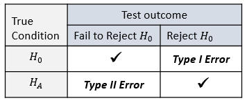

## Controlling Errors

- There is a *trade-off* between the two types of errors
- Significance level \(\alpha\) reflects *probability of making TYpe I Error*
  - Focus on controlling wrongful rejection of \(H_0\)
- Hypothesis testing *does not* controll Type II Error
  - Difficult in practice, must consider *all* alternatives

## Example

- Consider \(H_0: \mu \leq 0\) vs \(H_A: \mu > 0\)
  - *Specific* alternative (e.g. \(\mu=.5\)) allows calculation of Type II Error probability (called \(\beta\))

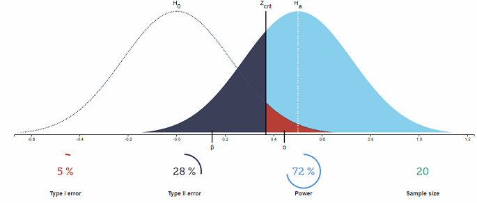

(https://rpsychologist.com/d3/NHST/)

## Statistical Power

- For fixed \(\alpha\), every test has *same* probability of Type I Error
  - Same chance of rejecting \(H_0\) when it is true
- But tests can have *different* Type II Error probabilities
  - *Power*: probability of rejecting \(H_0\) for *some* altervative in \(H_A\), i.e. Power = \(1-\beta\)
  - Want test to have good power against *all* alternatives
- In hypothesis testing, *presume* \(H_0\)
  - P-value checks whether data are *inconsistent* with \(H_0\)
  - Power tells us how *discerning* test is w.r.t. alternatives

## Effect Size

- Assume you *reject* \(H_0: \mu = 0\) in favor of \(H_A: \mu \neq 0\)
  - Test says data are *unlikely* to have come from \(H_0\)
  - Doesn't specify how *far* they are from \(H_0\)
- E.g. can have same P-value for: large \(n\) & small \(\hat{\mu}\), or small \(n\) & large \(\hat{\mu}\)
- **Effect size** measures *magnitude* of phenomenon, irrespective of sample size
  - (In practive, all tests *eventually reject* \(H_0\) given enough data)
  - Effect sizes are important for Power/sample size calculations, and for combining results of multiple studies

## Example

- Found *statistically significant* (P-value < \(10^{-15}\)) gender pay differences at BSc level

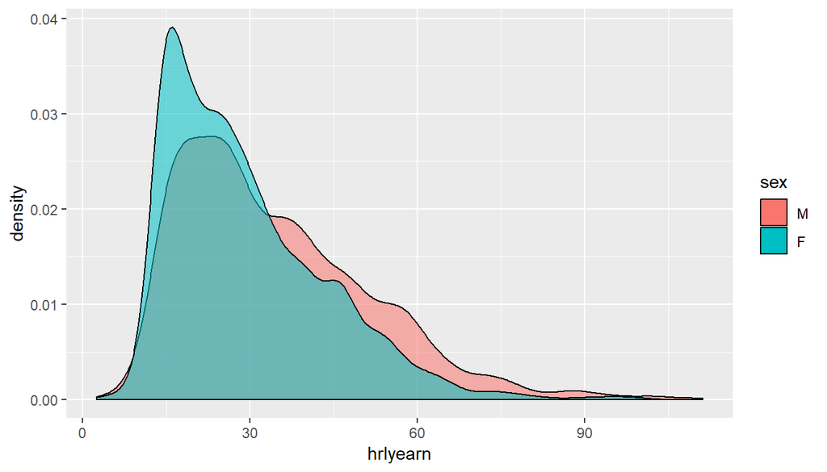

## Example

- Effect size for means measured by (Cohen's) \(d = \frac{ \hat{\mu}_1 - \hat{\mu}_2 }{S_{pooled}}\)
  - \(S_{pooled}\) measures combined variability

```r
library(effsize)
lfs %>% filter( educ == 5 ) %>%
  mutate( sex = factor(sex) ) %>%
  cohen.d( hrlyearn ~ sex, data = .)
##
## Cohen's d
##
## d estimate: 0.3361159 (small)
## 95 percent confidence interval:
##     lower     upper
## 0.2947876 0.3774442
```

## Effect Size

- Typical interpretation of effect sizes

| Size | Effect |
| --- | --- |
| \(0.0 - 0.2\) | Negligible |
| \(0.2 - 0.5\) | Small |
| \(0.5 - 0.8\) | Medium |
| \(0.8+\) | Large |

## Effect Size Interpretation

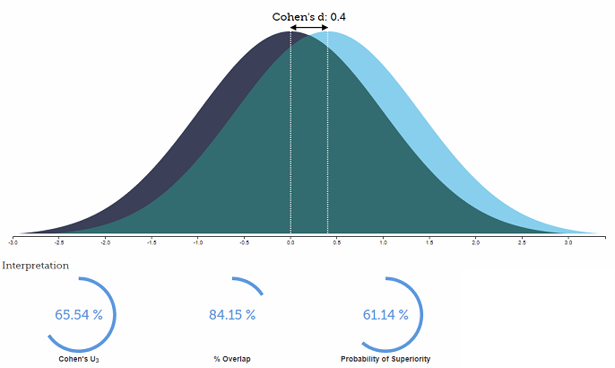

(https://rpsychologist.com/d3/cohend/)

## Power, Effect & Sample Size

- Always report sample & effect sizes for your test (not just P-value)
  - Help quantify importance and combine with other studies ([meta-analysis](https://en.wikipedia.org/wiki/Meta-analysis))
- Use power *prior to study*, to determine required *sample size*
  - How many observations are needed to discern effect (correctly reject \(H_0\)) of size d with desired power (1-\(\beta\)) for a given significance (\(\alpha\))?
  - E.g. for \(\alpha = 5\%, d = .40, 1-\beta = 80\% \Rightarrow n = 49\) (https://rpsychologist.com/d3/NHST/)
- *No point* in performing power calculations *after* test

## Critique of Hypothesis Testing

- In many disciplines, hypothesis testing became the standard of scientific discovery
  - Statistical significance was threshold to academic publishing
- Poor scientific practices, arbitrary defaults (\(\alpha = 5\%\)), and outright manipulation led to a [*replication crisis*](https://en.wikipedia.org/wiki/Replication_crisis)
  - See [Why Most Published Research Findings Are False](https://journals.plos.org/plosmedicine/article?id=10.1371/journal.pmed.0020124)
- Most common offender is [*Data-snooping*](https://en.wikipedia.org/wiki/Data_dredging) (aka p-hacking, data-dredging/fishing)

## Data Snooping

[figure not shown]

(https://imgs.xkcd.com/comics/significant.png)

## Data Snooping

- At 5% significance, expect 1 in 20 (independent) tests to Reject \(H_0\) even when it is true!
- Snoop around data long engough, and you are *almost guaranteed* to find significant results at 5% level
- Prevent data-snooping by separating *exploratory* from *confirmatory* data analysis
  - Keep search for & test of hypotheses apart

## Best Practices

How to prevent hypothesis testing misuse

- [*Study pre-registration*](https://www.pnas.org/content/115/11/2600): specify research questions & methodology *prior* to data-collection \(\rightarrow\) prevent data-snooping
- *Computational Reproducibility*: publish all data & code for analysis \(\rightarrow\) prevent errors/manipulation
- Report *both positive and negative* results \(\rightarrow\) prevent [publication bias](https://en.wikipedia.org/wiki/Publication_bias)